# Geospatial Risk Prediction in Philadelphia, PA

```r
policeDistricts <-
  st_read("Boundaries_District.geojson", quiet = TRUE) %>%
  st_transform('ESRI:102729') %>%
  dplyr::select(District = DIST_NUM)

crimes <-
  read.csv("incidents_part1_part2_2021.csv")

mischief <-
  crimes %>%
    filter(text_general_code == "Vandalism/Criminal Mischief",
           lat > -1) %>%
    dplyr::select(lat, lng) %>%
    na.omit() %>%
    st_as_sf(coords = c("lng", "lat"), crs = "EPSG:4326") %>%
    st_transform('ESRI:102729') %>%
    distinct()

hoods <-
  st_read("Neighborhoods_Philadelphia.geojson",
          quiet = TRUE) %>%
  st_transform('ESRI:102729')

vacant <-
  st_read("Vacant_Indicators_Points.geojson", quiet = TRUE) %>%
  st_transform('ESRI:102729')
```

## 1.Introduction

Vandalism/Criminal Mischief data is collected when there is law enforcement observing the incidents. A number of vandalism/criminal mischief can be missed in the data because some incidents can be unobserved and police officers can have bias to report events selectively. As a consequence, selection bias occurs and pose threat to the model.

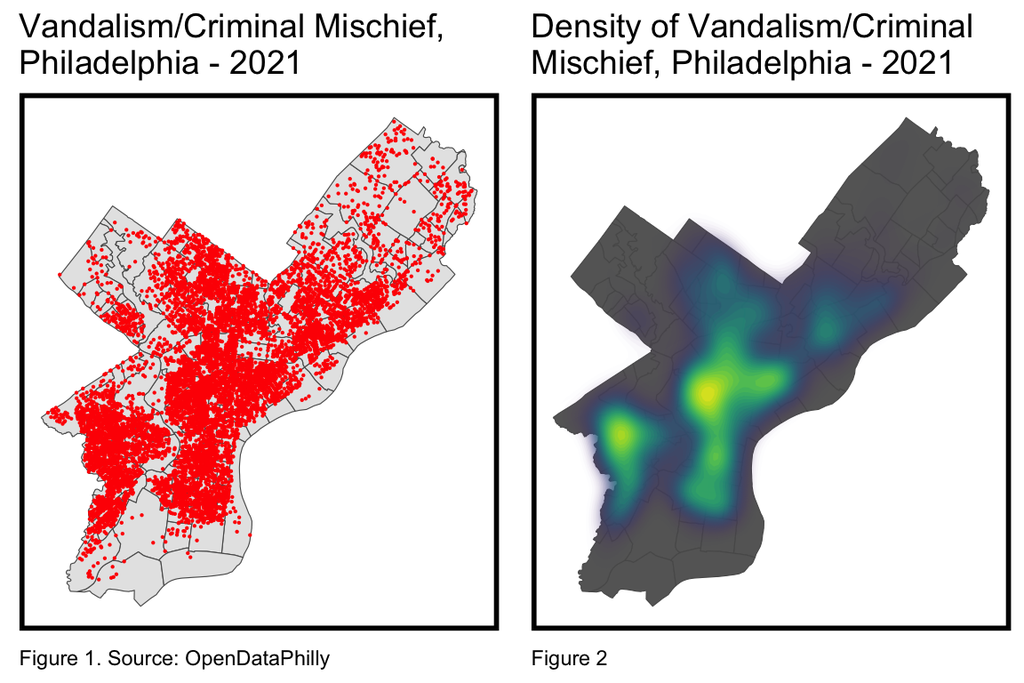

```r
# uses grid.arrange to organize independent plots
grid.arrange(ncol=2,
ggplot() +
  geom_sf(data = hoods) +
  geom_sf(data = mischief, colour="red", size=0.1, show.legend = "point") +
  labs(title= "Vandalism/Criminal Mischief,\nPhiladelphia - 2021",
       caption = "Figure 1. Source: OpenDataPhilly") +
  mapTheme(title_size = 14),

ggplot() +
  geom_sf(data = hoods, fill = "grey40") +
  stat_density2d(data = data.frame(st_coordinates(mischief)),
                 aes(X, Y, fill = ..level.., alpha = ..level..),
                 size = 0.01, bins = 40, geom = 'polygon') +
  scale_fill_viridis() +
  scale_alpha(range = c(0.00, 0.35), guide = FALSE) +
  labs(title = "Density of Vandalism/Criminal\nMischief, Philadelphia - 2021",
       caption = "Figure 2") +
  mapTheme(title_size = 14) + theme(legend.position = "none"))
```

```r
## using {sf} to create the grid
fishnet <-
  st_make_grid(hoods,
               cellsize = 1640,
               square = TRUE) %>%
  .[hoods] %>%            # fast way to select intersecting polygons
  st_sf() %>%
  mutate(uniqueID = 1:n())
```

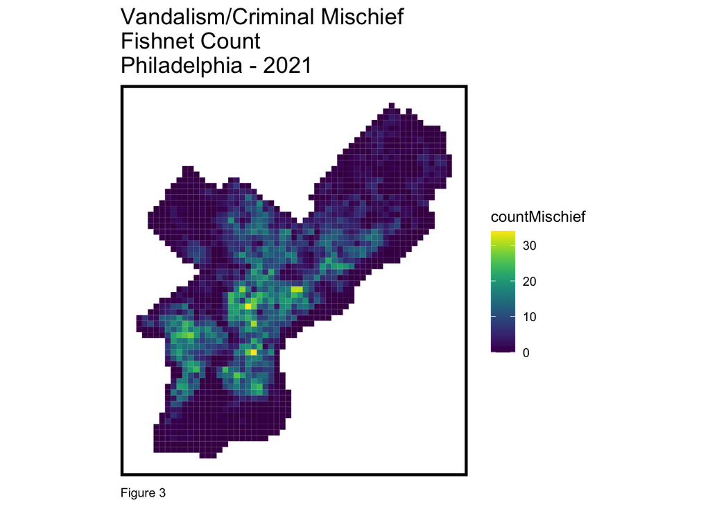

```r
## add a value of 1 to each crime, sum them with aggregate
crime_net <-
  dplyr::select(mischief) %>%
  mutate(countMischief = 1) %>%
  aggregate(., fishnet, sum) %>%
  mutate(countMischief = replace_na(countMischief, 0),
         uniqueID = 1:n(),
         cvID = sample(round(nrow(fishnet) / 24),
                       size=nrow(fishnet), replace = TRUE))

ggplot() +
  geom_sf(data = crime_net, aes(fill = countMischief), color = NA) +
  scale_fill_viridis() +
  labs(title = "Vandalism/Criminal Mischief\nFishnet Count\nPhiladelphia - 2021",
       caption = "Figure 3") +
  mapTheme()
```

A high concentration of Vandalism/Criminal Mischief incidents have been observed in the central, northern and western part of Philadelphia.

## 2. Risk Factors

```r
## only pulling a single variable for our model to keep it simple
## using Socrata again
dumping <-
  read.csv("public_cases_fc.csv") %>%
    filter(subject == "Illegal Dumping") %>%
    dplyr::select(Y = lat, X = lon) %>%
    na.omit() %>%
    st_as_sf(coords = c("X", "Y"), crs = 4326, agr = "constant") %>%
    st_transform(st_crs(fishnet)) %>%
    mutate(Legend = "Illegal_Dumping") %>%
    distinct()

abandonedCars <-
  read.csv("public_cases_fc.csv") %>%
    filter(subject == "Abandoned Vehicle" | subject == "Abandoned Automobile") %>%
    dplyr::select(Y = lat, X = lon) %>%
    na.omit() %>%
    st_as_sf(coords = c("X", "Y"), crs = 4326, agr = "constant") %>%
    st_transform(st_crs(fishnet)) %>%
    mutate(Legend = "Abandoned_Cars") %>%
    distinct()

vacant <- vacant %>%
  dplyr::select(geometry) %>%
  mutate(Legend = "Vacant_Property") %>%
  distinct()

allVars <- rbind(dumping, abandonedCars, vacant)
```

```r
vars_net <- allVars %>%
  st_join(fishnet, join=st_within) %>%
  st_drop_geometry() %>%
  group_by(uniqueID, Legend) %>%
  summarize(count = n()) %>%
  left_join(fishnet, ., by = "uniqueID") %>%
  spread(Legend, count, fill=0) %>%
  dplyr::select(-`<NA>`) %>%
  ungroup()
```

```r
# convinience to reduce length of function names.
st_c    <- st_coordinates
st_coid <- st_centroid

## create NN from illegal dumping
vars_net <- vars_net %>%
    mutate(Illegal_Dumping.nn = nn_function(st_c(st_coid(vars_net)),
                                           st_c(dumping),
                                           k = 3),
           Abandoned_Cars.nn = nn_function(st_c(st_coid(vars_net)),
                                           st_c(abandonedCars),
                                           k = 3),
           Vacant_Property.nn = nn_function(st_c(st_coid(vars_net)),
                                           st_c(vacant),
                                           k = 3))
```

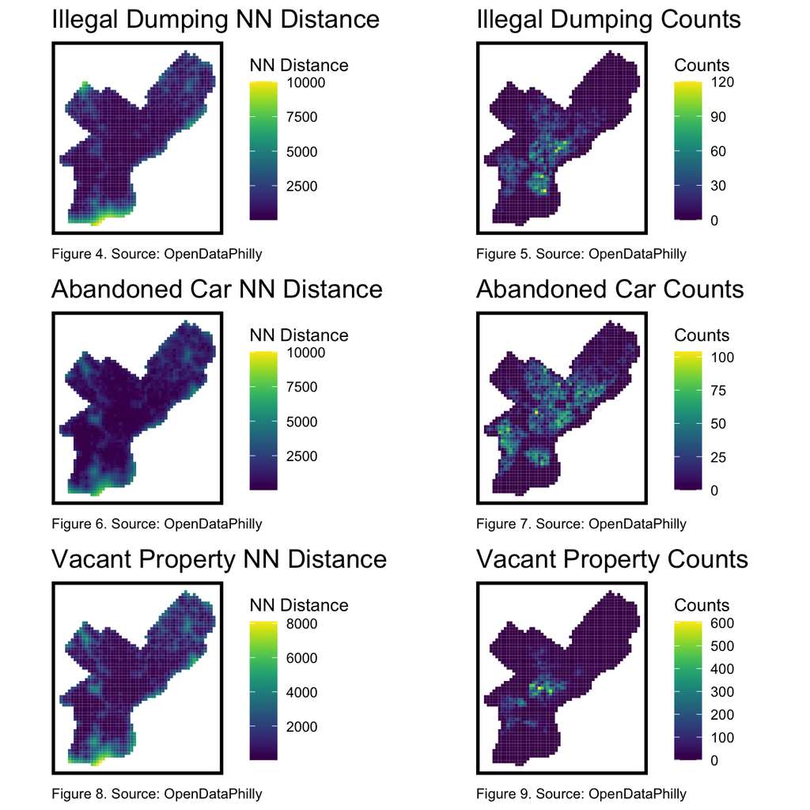

```r
## Visualize the NN feature
vars_net.long.nn <-
  dplyr::select(vars_net, ends_with(".nn")) %>%
    gather(Variable, value, -geometry)

grid.arrange(ncol=2,
ggplot() +
      geom_sf(data = vars_net, aes(fill=Illegal_Dumping.nn), colour=NA) +
      scale_fill_viridis(name="NN Distance") +
      labs(title="Illegal Dumping NN Distance",
      caption = "Figure 4. Source: OpenDataPhilly") +
      mapTheme(),

ggplot() +
      geom_sf(data = vars_net, aes(fill=Illegal_Dumping), colour=NA) +
      scale_fill_viridis(name="Counts") +
      labs(title="Illegal Dumping Counts",
      caption = "Figure 5. Source: OpenDataPhilly") +
      mapTheme(),

ggplot() +
      geom_sf(data = vars_net.long.nn, aes(fill=value), colour=NA) +
      scale_fill_viridis(name="NN Distance") +
      labs(title="Abandoned Car NN Distance",
      caption = "Figure 6. Source: OpenDataPhilly") +
      mapTheme(),

ggplot() +
      geom_sf(data = vars_net, aes(fill=Abandoned_Cars), colour=NA) +
      scale_fill_viridis(name="Counts") +
      labs(title="Abandoned Car Counts",
      caption = "Figure 7. Source: OpenDataPhilly") +
      mapTheme(),

ggplot() +
      geom_sf(data = vars_net, aes(fill=Vacant_Property.nn), colour=NA) +
      scale_fill_viridis(name="NN Distance") +
      labs(title="Vacant Property NN Distance",
      caption = "Figure 8. Source: OpenDataPhilly") +
      mapTheme(),

ggplot() +
      geom_sf(data = vars_net, aes(fill=Vacant_Property), colour=NA) +
      scale_fill_viridis(name="Counts") +
      labs(title="Vacant Property Counts",
      caption = "Figure 9. Source: OpenDataPhilly") +
      mapTheme())
```

```r
##important to drop the geometry from joining features
final_net <-
  left_join(crime_net, st_drop_geometry(vars_net), by="uniqueID")
```

```r
final_net <-
  st_centroid(final_net) %>%
    st_join(dplyr::select(hoods, name), by = "uniqueID") %>%
    st_join(dplyr::select(policeDistricts, District), by = "uniqueID") %>%
      st_drop_geometry() %>%
      left_join(dplyr::select(final_net, geometry, uniqueID)) %>%
      st_sf() %>%
  na.omit()
```

The risk factors we chose are Illegal Dumping, Abandoned Cars and Vacant Property, which could have high correlation with Vandalism/Criminal Mischief. All risk factors demonstrate a concentration in the city center, while illegal dumping and abandoned cars have higher density in northern Philadelphia.

## 3.The Spatial Process of Mischief

```r
## generates warnings from PROJ issues
## {spdep} to make polygon to neighborhoods...
final_net.nb <- poly2nb(as_Spatial(final_net), queen=TRUE)
## ... and neighborhoods to list of weigths
final_net.weights <- nb2listw(final_net.nb, style="W", zero.policy=TRUE)

# print(final_net.weights, zero.policy=TRUE)
```

```r
## see ?localmoran
local_morans <- localmoran(final_net$countMischief, final_net.weights, zero.policy=TRUE) %>%
  as.data.frame()

# join local Moran's I results to fishnet
final_net.localMorans <-
  cbind(local_morans, as.data.frame(final_net)) %>%
  st_sf() %>%
  dplyr::select(Illegal_Dumping,
                Abandoned_Cars,
                Vacant_Property,
                Local_Morans_I = Ii,
                P_Value = `Pr(z != E(Ii))`) %>%
  mutate(Significant_Hotspots = ifelse(P_Value <= 0.001, 1, 0)) %>%
  gather(Variable, Value, -geometry)
```

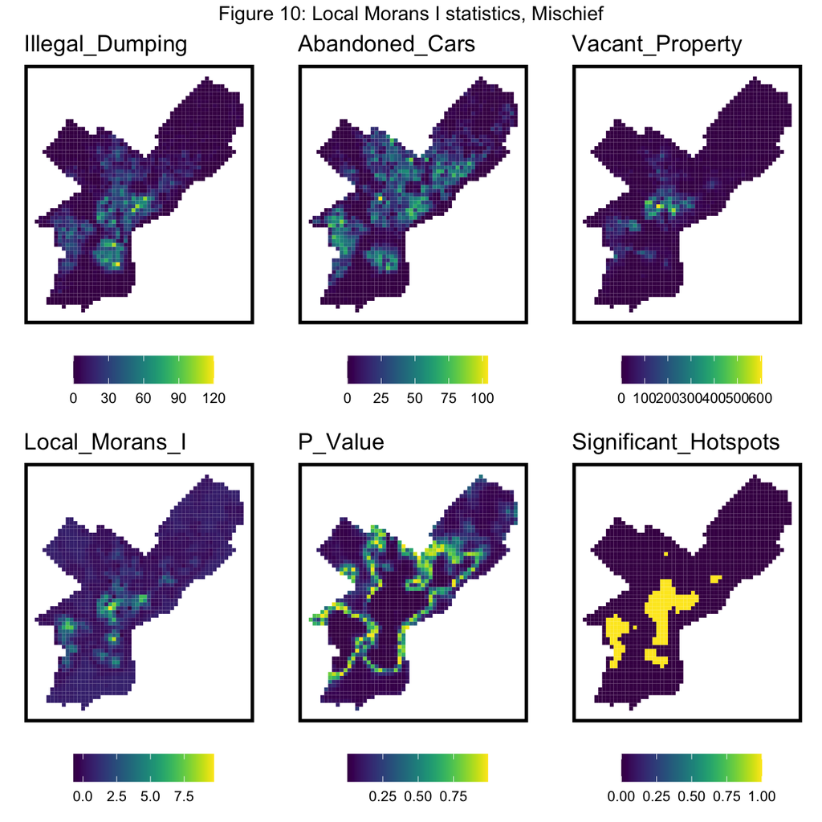

```r
vars <- unique(final_net.localMorans$Variable)
varList <- list()

for(i in vars){
  varList[[i]] <-
    ggplot() +
      geom_sf(data = filter(final_net.localMorans, Variable == i),
              aes(fill = Value), colour=NA) +
      scale_fill_viridis(name="") +
      labs(title=i) +
      mapTheme(title_size = 14) + theme(legend.position="bottom")}

do.call(grid.arrange,c(varList, ncol = 3, top = "Figure 10: Local Morans I statistics, Mischief"))
```

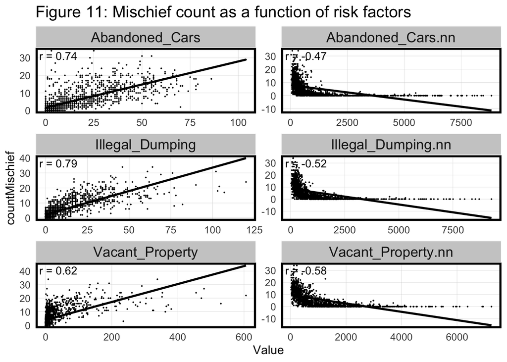

```r
correlation.long <-
  st_drop_geometry(final_net) %>%
    dplyr::select(-uniqueID, -cvID, -name, -District) %>%
    gather(Variable, Value, -countMischief)

correlation.cor <-
  correlation.long %>%
    group_by(Variable) %>%
    summarize(correlation = cor(Value, countMischief, use = "complete.obs"))

ggplot(correlation.long, aes(Value, countMischief)) +
  geom_point(size = 0.1) +
  geom_text(data = correlation.cor, aes(label = paste("r =", round(correlation, 2))),
            x=-Inf, y=Inf, vjust = 1.5, hjust = -.1) +
  geom_smooth(method = "lm", se = FALSE, colour = "black") +
  facet_wrap(~Variable, ncol = 2, scales = "free") +
  labs(title = "Figure 11: Mischief count as a function of risk factors") +
  plotTheme()
```

As is shown in Figure 11, the count of Vandalism/Criminal Mischief is more correlated with the count abandoned cars and illegal dumping than vacant housing. The nearest neighbor feature of each risk factor is less correlated than the counts.

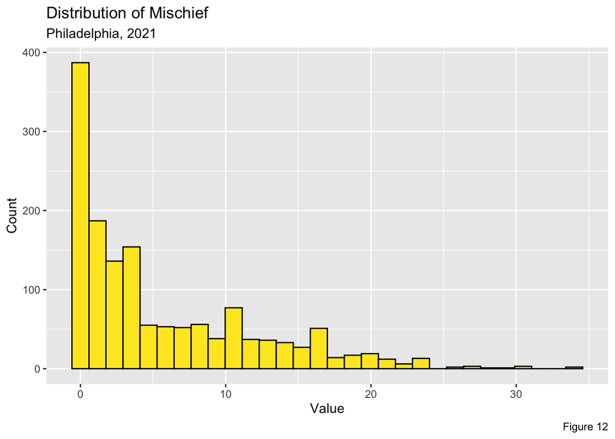

```r
  ggplot(data = final_net, aes(countMischief)) +
    geom_histogram(bins = 30, colour="black", fill = "#FDE725FF") +
    labs(title="Distribution of Mischief", subtitle = "Philadelphia, 2021",
         caption = "Figure 12",
         x="Value", y="Count")
```

Almost 400 fishnets have no Mischief incidents, with a large number of the fishnets have less than 10 incidents.

## 4.Regression Modeling

### 4.1 Cross-validation Poisson Regression

```r
# View(crossValidate)

## define the variables we want
reg.vars <- c("Illegal_Dumping", "Vacant_Property")

## RUN REGRESSIONS
#k-fold
reg.CV <- crossValidate(
  dataset = final_net,
  id = "cvID",
  dependentVariable = "countMischief",
  indVariables = reg.vars) %>%
    dplyr::select(cvID, countMischief, Prediction, geometry)

#spatial process
reg.spatialCV <- crossValidate(
  dataset = final_net,
  id = "name",
  dependentVariable = "countMischief",
  indVariables = reg.vars) %>%
    dplyr::select(cvID = name, countMischief, Prediction, geometry)

reg.summary <-
  rbind(
    mutate(reg.CV,           Error = Prediction - countMischief,
                             Regression = "Random k-fold CV"),
    mutate(reg.spatialCV,    Error = Prediction - countMischief,
                             Regression = "Spatial LOGO-CV")
 ) %>%
    st_sf()
```

### 4.2 Accuracy and Generalizability

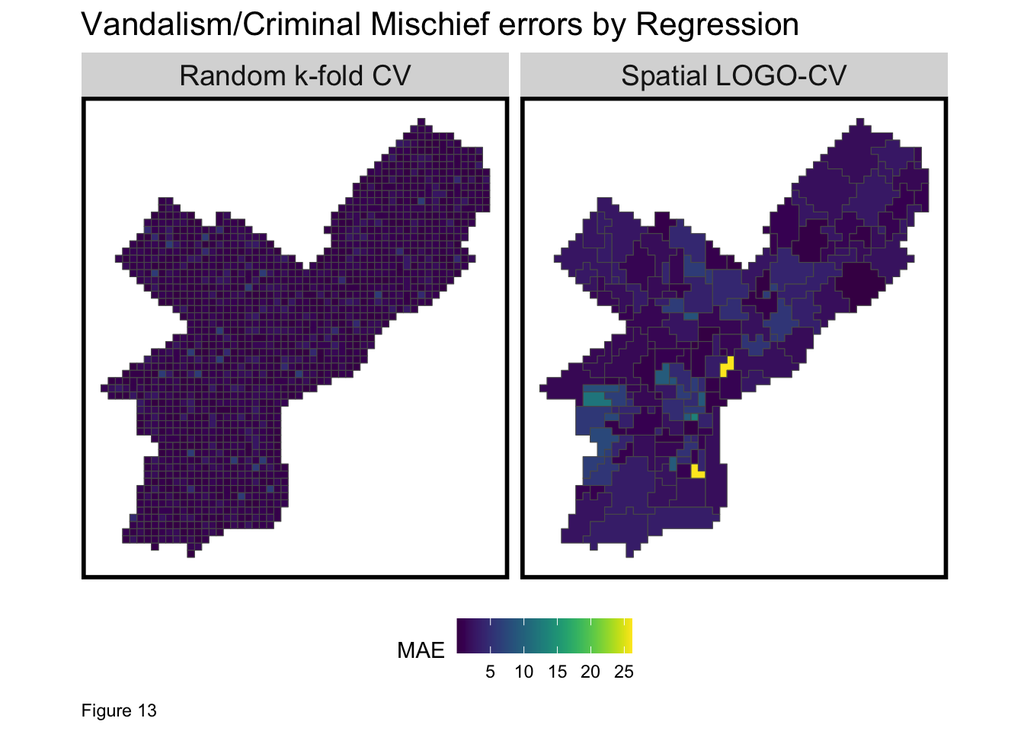

```r
# calculate errors by NEIGHBORHOOD
error_by_reg_and_fold <-
  reg.summary %>%
    group_by(Regression, cvID) %>%
    summarize(Mean_Error = mean(Prediction - countMischief, na.rm = T),
              MAE = mean(abs(Mean_Error), na.rm = T),
              SD_MAE = sd(abs(Mean_Error), na.rm = T)) %>%
  ungroup()


error_by_reg_and_fold %>%
  #filter(str_detect(Regression, "LOGO")) %>%
  ggplot() +
    geom_sf(aes(fill = MAE)) +
    facet_wrap(~Regression) +
    scale_fill_viridis() +
    labs(title = "Vandalism/Criminal Mischief errors by Regression",
         caption = "Figure 13") +
    mapTheme() + theme(legend.position="bottom")
```

The maps demonstrate that there are two areas in Philadelphia with significant error compared with the rest of the city, which indicates the model is somewhat inaccurate.

```r
st_drop_geometry(error_by_reg_and_fold) %>%
  group_by(Regression) %>%
    summarize(Mean_MAE = round(mean(MAE), 2),
              SD_MAE = round(sd(MAE), 2)) %>%
  kable(caption = "Figure 14: Error by Regression") %>%
    kable_styling("striped", full_width = F ) %>%
    row_spec(2, color = "black", background = "#FDE725FF") %>%
    row_spec(2, color = "black", background = "#FDE725FF")
```

[output not shown]

```r
census_api_key("730e334cd384273fdcda9984e41c6444518d82d6", overwrite = TRUE)
```

```r
varslist = c("B02001_001E", "B02001_002E")

tracts <-
  get_acs(geography = "tract",
          variables = varslist,
          year=2021, state=42,
          county=101, output="wide", geometry=TRUE) %>%
  st_transform('ESRI:102729')

tracts <- tracts %>%
  dplyr::select(GEOID, NAME, all_of(varslist))

tracts <- tracts %>%
  rename(TotPop = B02001_001E,  White = B02001_002E) %>%
  mutate(whitePct = White/TotPop)

tracts <-
  tracts %>%
  mutate(raceContext = ifelse(whitePct > 0.5, "Majority White", "Majority Non-White")) %>%
  na.omit()
```

```r
reg.summary %>%
    st_centroid() %>%
    st_join(tracts) %>%
    na.omit() %>%
      st_drop_geometry() %>%
      group_by(Regression, raceContext) %>%
      summarize(mean.Error = mean(Error, na.rm = T)) %>%
      spread(raceContext, mean.Error) %>%
      kable(caption = "Figure 15: Mean Error by neighborhood racial context") %>%
        kable_styling("striped", full_width = F)
```

Figure 15: Mean Error by neighborhood racial context

| Regression | Majority Non-White | Majority White |
| --- | --- | --- |
| Random k-fold CV | -2.083125 | 1.16362 |
| Spatial LOGO-CV | -2.093122 | 1.18960 |

Figure 15 shows that the majortiy-white and majority-non-white areas have biased result based on the model.

```r
crimes2022 <-
  read.csv("incidents_part1_part2_2022.csv")

mischief2022 <-
  crimes2022 %>%
    filter(text_general_code == "Vandalism/Criminal Mischief",
           lat > -1) %>%
    dplyr::select(lat, lng) %>%
    na.omit() %>%
    st_as_sf(coords = c("lng", "lat"), crs = "EPSG:4326") %>%
    st_transform('ESRI:102729') %>%
    distinct() %>%
    .[fishnet,]
```

```r
# demo of kernel width
mischief_ppp <- as.ppp(st_coordinates(mischief), W = st_bbox(final_net))
mischief_KD.1000 <- spatstat.explore::density.ppp(mischief_ppp, 1000)
mischief_KD.1500 <- spatstat.explore::density.ppp(mischief_ppp, 1500)
mischief_KD.2000 <- spatstat.explore::density.ppp(mischief_ppp, 2000)
mischief_KD.df <- rbind(
  mutate(data.frame(rasterToPoints(mask(raster(mischief_KD.1000), as(hoods, 'Spatial')))), Legend = "1000 Ft."),
  mutate(data.frame(rasterToPoints(mask(raster(mischief_KD.1500), as(hoods, 'Spatial')))), Legend = "1500 Ft."),
  mutate(data.frame(rasterToPoints(mask(raster(mischief_KD.2000), as(hoods, 'Spatial')))), Legend = "2000 Ft."))

mischief_KD.df$Legend <- factor(mischief_KD.df$Legend, levels = c("1000 Ft.", "1500 Ft.", "2000 Ft."))
```

```r
mischief_KDE_sum <- as.data.frame(mischief_KD.1000) %>%
  st_as_sf(coords = c("x", "y"), crs = st_crs(final_net)) %>%
  aggregate(., final_net, mean)
kde_breaks <- classIntervals(mischief_KDE_sum$value,
                             n = 5, "fisher")
mischief_KDE_sf <- mischief_KDE_sum %>%
  mutate(label = "Kernel Density",
         Risk_Category = classInt::findCols(kde_breaks),
         Risk_Category = case_when(
           Risk_Category == 5 ~ "5th",
           Risk_Category == 4 ~ "4th",
           Risk_Category == 3 ~ "3rd",
           Risk_Category == 2 ~ "2nd",
           Risk_Category == 1 ~ "1st")) %>%
  cbind(
    aggregate(
      dplyr::select(mischief2022) %>% mutate(mischiefCount = 1), ., sum) %>%
    mutate(mischiefCount = replace_na(mischiefCount, 0))) %>%
  dplyr::select(label, Risk_Category, mischiefCount)

ml_breaks <- classIntervals(reg.CV$Prediction,
                             n = 5, "fisher")
mischief_risk_sf <-
  reg.CV %>%
  mutate(label = "Risk Predictions",
         Risk_Category =classInt::findCols(ml_breaks),
         Risk_Category = case_when(
           Risk_Category == 5 ~ "5th",
           Risk_Category == 4 ~ "4th",
           Risk_Category == 3 ~ "3rd",
           Risk_Category == 2 ~ "2nd",
           Risk_Category == 1 ~ "1st")) %>%
  cbind(
    aggregate(
      dplyr::select(mischief2022) %>% mutate(mischiefCount = 1), ., sum) %>%
      mutate(mischiefCount = replace_na(mischiefCount, 0))) %>%
  dplyr::select(label,Risk_Category, mischiefCount)
```

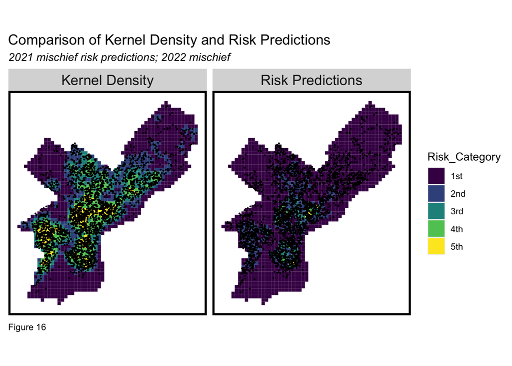

```r
rbind(mischief_KDE_sf, mischief_risk_sf) %>%
  na.omit() %>%
  gather(Variable, Value, -label, -Risk_Category, -geometry) %>%
  ggplot() +
    geom_sf(aes(fill = Risk_Category), colour = NA) +
    geom_sf(data = sample_n(mischief2022, 3000), size = .2, colour = "black") +
    facet_wrap(~label, ) +
    scale_fill_viridis(discrete = TRUE) +
    labs(title="Comparison of Kernel Density and Risk Predictions",
         subtitle="2021 mischief risk predictions; 2022 mischief",
         caption = "Figure 16") +
    mapTheme(title_size = 14)
```

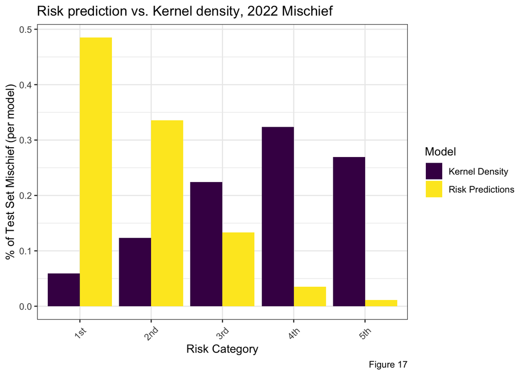

```r
rbind(mischief_KDE_sf, mischief_risk_sf) %>%
  st_drop_geometry() %>%
  na.omit() %>%
  gather(Variable, Value, -label, -Risk_Category) %>%
  group_by(label, Risk_Category) %>%
  summarize(countMischief = sum(Value)) %>%
  ungroup() %>%
  group_by(label) %>%
  mutate(Pcnt_of_test_set_crimes = countMischief / sum(countMischief)) %>%
    ggplot(aes(Risk_Category,Pcnt_of_test_set_crimes)) +
      geom_bar(aes(fill=label), position="dodge", stat="identity") +
      scale_fill_viridis(discrete = TRUE, name = "Model") +
      labs(title = "Risk prediction vs. Kernel density, 2022 Mischief",
           y = "% of Test Set Mischief (per model)",
           x = "Risk Category",
           caption = "Figure 17") +
  theme_bw() +
      theme(axis.text.x = element_text(angle = 45, vjust = 0.5))
```

It is shown in the maps and chart that our model under-predicts the Vandalism/Criminal Mischief incidents.

## Reasons why I would not recommend the algorithm

This algorithm aims to predict the risk of Vandalism/Criminal Mischief in Philadelphia based on historical data and spatial features. However, I might not recommend the algorithm because of the following reasons.

One reason is that the algorithm can have selection bias. It may not account for the additional factors that influence how police patrol certain areas, which could affect the reported Vandalism/Criminal Mischief rates. If we put biased data into the model, we will only receive biased result.

Another reason is that the algorithm may pose threat to the people who are affected by its predictions. If this algorithm is used, it can contribute to more surveillance and oppression in the neighborhoods suffering from disadvantages.